# 第6回 データの加工（2）：データの集計と要約統計量の算出

行動計量学（行動科学分析法入門）

小野原 彩香

令和8年度

## 本日の目標

1. `group_by()` + `summarise()` でグループ別集計ができる
2. `count()` でカテゴリの頻度を集計できる
3. 集計結果を `ggplot2` でグラフ化できる

## 準備：パッケージの読み込み

この回のコードは，すべて `tidyverse` を読み込んだ状態で動きます。 RStudioを起動したら，**まずこれを実行してください。**

```r
library(tidyverse)
```

> 毎回必要です。読み込まないまま `filter()` や `ggplot()` を使うと， 「関数が見つかりません」というエラーになります。

## 1. summarise()：集計

`summarise()` はデータ全体を1行（または数行）に集約します。

```r
# msleep の全体の睡眠時間の平均
msleep |>
  summarise(mean_sleep = mean(sleep_total, na.rm = TRUE))
```

| mean_sleep |
| --- |
| 10.43373 |

```r
# 複数の統計量をまとめて計算
msleep |>
  summarise(
    n = n(),
    mean_sleep = mean(sleep_total, na.rm = TRUE),
    sd_sleep   = sd(sleep_total, na.rm = TRUE),
    min_sleep  = min(sleep_total, na.rm = TRUE),
    max_sleep  = max(sleep_total, na.rm = TRUE)
  )
```

| n | mean_sleep | sd_sleep | min_sleep | max_sleep |
| --- | --- | --- | --- | --- |
| 83 | 10.43373 | 4.450357 | 1.9 | 19.9 |

### よく使う集計関数

| 関数 | 意味 |
| --- | --- |
| `mean(x, na.rm=TRUE)` | 平均値 |
| `sd(x, na.rm=TRUE)` | 標準偏差 |
| `median(x, na.rm=TRUE)` | 中央値 |
| `min(x)` / `max(x)` | 最小値 / 最大値 |
| `n()` | データ件数 |
| `sum(x, na.rm=TRUE)` | 合計 |

> `na.rm = TRUE` は欠損値（NA）を除いて計算するオプションです。

## 2. group_by() + summarise()：グループ別集計

`group_by()` と `summarise()` を組み合わせると，グループごとに集計できます。

```r
# 食性（vore）ごとの平均睡眠時間
msleep |>
  group_by(vore) |>
  summarise(
    n = n(),
    mean_sleep = mean(sleep_total, na.rm = TRUE),
    sd_sleep   = sd(sleep_total, na.rm = TRUE)
  )
```

| vore | n | mean_sleep | sd_sleep |
| --- | --- | --- | --- |
| carni | 19 | 10.378947 | 4.669116 |
| herbi | 32 | 9.509375 | 4.878746 |
| insecti | 5 | 14.940000 | 5.920557 |
| omni | 20 | 10.925000 | 2.949019 |
| NA | 7 | 10.185714 | 3.004124 |

### 出てきた `<NA>` の行は何か

出力の最後に `<NA>` という行があります。**これは「NAという食性」ではありません。** `msleep` には**食性が記録されていない動物が7種**あり，その7種がひとまとめにされて集計されています。

`group_by()` は，欠損値も1つのグループとして扱います。黙って捨てたりはしません。 「そういうデータがある」と見せてくれている，と考えてください。

> **この行をどう扱うかは，分析する人が決めます。**
> - 食性どうしを比べるのが目的なら，**除く**（4節でそうしています）
> - 「食性が不明な動物がこれだけいる」こと自体が情報なら，**残す**

> どちらでも構いませんが，**除いたことを自覚しておく**のが大事です。 気づかないうちに7種が消えているのと，理由があって除くのとは違います。

```r
# irisデータ：種ごとの平均と標準偏差
iris |>
  group_by(Species) |>
  summarise(
    n = n(),
    mean_sepal = mean(Sepal.Length),
    sd_sepal   = sd(Sepal.Length),
    mean_petal = mean(Petal.Length),
    sd_petal   = sd(Petal.Length)
  )
```

| Species | n | mean_sepal | sd_sepal | mean_petal | sd_petal |
| --- | --- | --- | --- | --- | --- |
| setosa | 50 | 5.006 | 0.3524897 | 1.462 | 0.1736640 |
| versicolor | 50 | 5.936 | 0.5161711 | 4.260 | 0.4699110 |
| virginica | 50 | 6.588 | 0.6358796 | 5.552 | 0.5518947 |

## 3. count()：カテゴリの頻度集計

```r
# 食性ごとの件数
msleep |>
  count(vore)
```

| vore | n |
| --- | --- |
| carni | 19 |
| herbi | 32 |
| insecti | 5 |
| omni | 20 |
| NA | 7 |

```r
# 降順で並べる
msleep |>
  count(vore, sort = TRUE)
```

| vore | n |
| --- | --- |
| herbi | 32 |
| omni | 20 |
| carni | 19 |
| NA | 7 |
| insecti | 5 |

## 4. 集計結果をグラフ化する

### 棒グラフ（平均値の比較）

ここでは食性どうしを比べたいので，2節で見た `<NA>` の行を **`filter(!is.na(vore))` で除いてから**集計します。

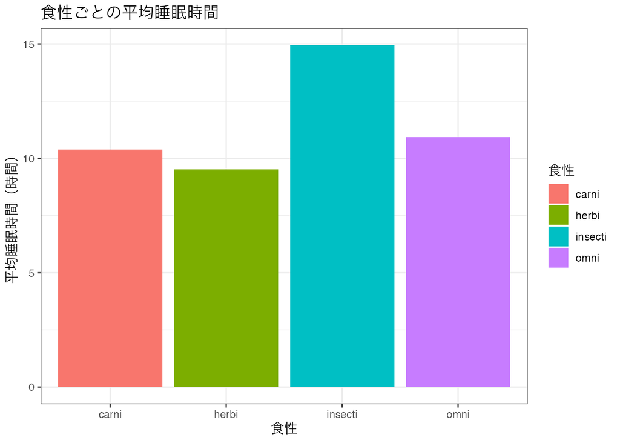

```r
# 集計データを作成
sleep_summary <- msleep |>
  filter(!is.na(vore)) |>
  group_by(vore) |>
  summarise(
    mean_sleep = mean(sleep_total, na.rm = TRUE),
    sd_sleep   = sd(sleep_total, na.rm = TRUE),
    n          = n()
  )

# 棒グラフ（geom_col で集計済みデータを使う）
ggplot(sleep_summary, aes(x = vore, y = mean_sleep, fill = vore)) +
  geom_col() +
  labs(title = "食性ごとの平均睡眠時間",
       x = "食性", y = "平均睡眠時間（時間）",
       fill = "食性") +
  theme_bw()
```

### エラーバー付き棒グラフ

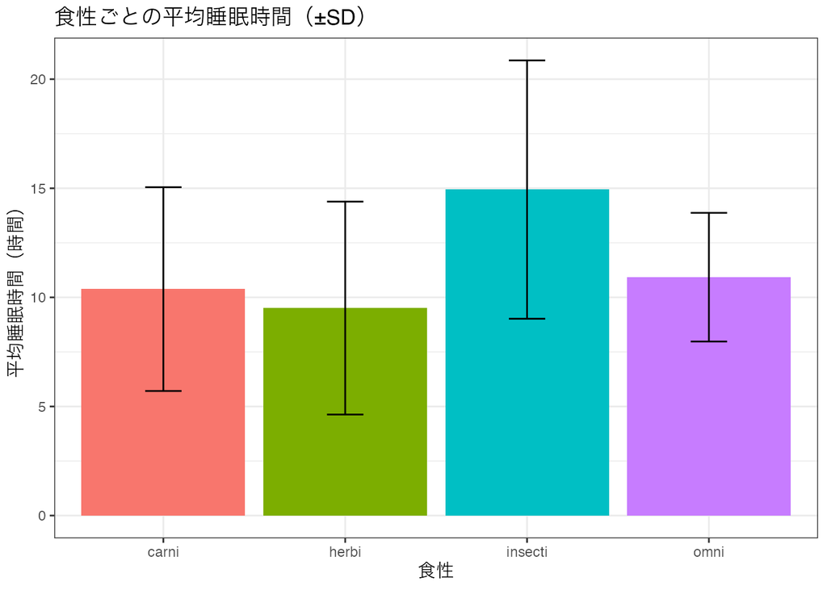

```r
ggplot(sleep_summary, aes(x = vore, y = mean_sleep, fill = vore)) +
  geom_col() +
  geom_errorbar(aes(ymin = mean_sleep - sd_sleep,
                    ymax = mean_sleep + sd_sleep),
                width = 0.2) +
  labs(title = "食性ごとの平均睡眠時間（±SD）",
       x = "食性", y = "平均睡眠時間（時間）") +
  theme_bw() +
  theme(legend.position = "none")
```

## 5. 欠損値の扱い

```r
# 欠損値がある列の確認
msleep |>
  summarise(across(everything(), ~ sum(is.na(.))))
```

| name | genus | vore | order | conservation | sleep_total | sleep_rem | sleep_cycle | awake | brainwt | bodywt |
| --- | --- | --- | --- | --- | --- | --- | --- | --- | --- | --- |
| 0 | 0 | 7 | 0 | 29 | 0 | 22 | 51 | 0 | 27 | 0 |

```r
# 欠損値を除いて集計（na.rm = TRUE）
msleep |>
  summarise(mean_rem = mean(sleep_rem, na.rm = TRUE))
```

| mean_rem |
| --- |
| 1.87541 |

> **`n()` と `na.rm = TRUE` を並べるときは注意してください。**

> `n()` は**行数**を数えるだけで，欠損があるかどうかは見ていません。 一方 `mean(x, na.rm = TRUE)` は欠損を除いて計算します。 つまり同じ `summarise()` の中に並べると，**`n` と「平均に使われた件数」がずれます。**

> ```r
> msleep |>
>   summarise(n = n(), mean_brain = mean(brainwt, na.rm = TRUE))
> # n は 83 と出るが，平均に使われたのは 56 件（brainwt は27件が欠損）
> ```

> 実際に使われた件数を数えたいときは `sum(!is.na(brainwt))` を使います。 レポートや論文で n を書くときは，**どちらの数字なのかをはっきりさせてください。**

```r
# 欠損値のある行を除いてから集計
msleep |>
  filter(!is.na(sleep_rem)) |>
  group_by(vore) |>
  summarise(
    n = n(),
    mean_rem = mean(sleep_rem)
  )
```

| vore | n | mean_rem |
| --- | --- | --- |
| carni | 10 | 2.290000 |
| herbi | 24 | 1.366667 |
| insecti | 4 | 3.525000 |
| omni | 18 | 1.955556 |
| NA | 5 | 1.880000 |

## 6. 実際のCSVファイルの読み込み

ここまではRに最初から入っているデータを使ってきました。 自分で集めたデータを読み込むときは，次のように書きます。

```r
# CSVファイルの読み込み（readr パッケージ，tidyverse に含まれる）
my_data <- read_csv("data/my_data.csv")
```

### 日本語が化けるとき ―― 文字コードの問題

`read_csv()` は **UTF-8** という文字コードを前提にしています。 ところが **Windows版のExcelで「CSV（コンマ区切り）」として保存すると，多くの場合 Shift_JIS（CP932）になります。** この食い違いが起きると，こうなります。

```
> my_data
  \x92n\x88\xe6 \x90l\x90\x94
1 \x93\x8c\x8b\x9e           10
2       \x8eD\x96y           20
```

本来は `地域` `人数` `東京` `札幌` と表示されるはずのところが，`\x` で始まる記号の列になります。

> **これが一番やりにくい点です。** **エラーで止まりません。** 読み込み自体は成功してしまうので，気づかないまま集計や作図に進み， グラフの軸ラベルが記号だらけになって初めて気づく，ということが起きます。 読み込んだ直後に必ず中身を表示して，日本語が読めているか確認してください。

対処は2つあります。

**① 読み込むときに文字コードを指定する**

```r
# Windows版Excelで保存したCSVは，たいていこちら
my_data <- read_csv("data/my_data.csv", locale = locale(encoding = "CP932"))

# すでにUTF-8になっているCSV（指定しなくても読めます）
my_data <- read_csv("data/my_data.csv", locale = locale(encoding = "UTF-8"))
```

**② 保存するときにUTF-8にしておく（こちらを推奨）**

Excelの「名前を付けて保存」で，ファイルの種類を **`CSV UTF-8 (コンマ区切り)`** にします。 こうしておけば `read_csv()` に何も足さずに読めますし，他の人とデータを共有するときも安全です。

> どちらの文字コードか分からないときは，まず `read_csv()` だけで試してください。 化けていたら `locale = locale(encoding = "CP932")` を足す，という順番で構いません。

### Excelファイルを直接読む方法もあります

`.xlsx` のまま読めば，**文字コードの問題は起きません。**

```r
# install.packages("readxl")   # 最初の1回だけ
library(readxl)

my_data <- read_excel("data/my_data.xlsx")

# シートを指定する場合
my_data <- read_excel("data/my_data.xlsx", sheet = "データ")
```

Excelで管理しているデータなら，CSVに変換せずこちらのほうが確実です。

> `readxl` は tidyverse に含まれていないので，`install.packages("readxl")` が別に必要です。

## 演習

### 演習1：グループ別集計

`iris` データを使って，種（`Species`）ごとに以下を計算してください。

- `Petal.Length` の平均・標準偏差・サンプルサイズ

```r
iris |>
  group_by(___) |>
  summarise(
    n    = n(),
    mean = mean(___),
    sd   = sd(___)
  )
```

### 演習2：集計結果のグラフ化

演習1で作った集計結果を使って，エラーバー付きの棒グラフを作成してください。

```r
# まず集計
petal_summary <- iris |>
  group_by(Species) |>
  summarise(
    mean_petal = mean(Petal.Length),
    sd_petal   = sd(Petal.Length)
  )

# グラフ
ggplot(petal_summary, aes(x = ___, y = ___, fill = ___)) +
  geom_col() +
  geom_errorbar(aes(ymin = ___ - ___, ymax = ___ + ___), width = 0.2) +
  labs(title = "種ごとの花びらの長さ（平均±SD）",
       x = "___", y = "___") +
  theme_bw()
```

### 演習3：count()の応用

`msleep` の食性（`vore`）ごとのサンプルサイズを `count()` で集計し，多い順に並べてください。

> `vore` には欠損値（`NA`）が**7件**あります。`count()` はそのまま使うと `NA` も1つのカテゴリとして数えます。**今回は `NA` を除いて集計してください。**

## 本日のまとめ

- `summarise()` でデータを集計できる
- `group_by()` と組み合わせるとグループ別集計が可能
- `count()` でカテゴリの頻度を数えられる
- 集計結果を `ggplot2` でグラフ化できる
- `na.rm = TRUE` で欠損値を除いた計算ができる

## 宿題・予習

- 本日の演習を仕上げ，スクリプトを保存しておく
- 次回は**習熟度確認テスト（第1回）**と復習です
- 第2〜6回で学んだ内容（可視化・加工）を見直しておく